# “Density on density nonparametric regression: simulation scheme 3”

Frédéric Ferraty

3/24/2021

## Set parameters

```r
grid.size = 200 # number of equidistant points where the PDFs are valued
Grid = seq(-1, 1, length = grid.size) # Grid of 'grid.size' equidistant points over [-1, 1] where the PDFs are valued
nbtrigof = 5 # number of trigonometric functions used for building the model error
sigma = 0.2 # standard deviation of the distribution drawing the coefficients used to build model error
N = 100 # sample size
lower = -1 # lower bound of the support of PDFs (Bayes Hilbert space)
upper = 1 # upper bound of the support of PDFs (Bayes Hilbert space)
nu = 0.5 # standard deviation of the truncated distribution (error-in-variable)
rho = 0.9 # mixing coefficient
T = 300 # parameter used to simulate truncated normal distribution
```

Remarks:

- lower values for *rho* and higher values for *nu* make the complexity of the regession model higher (and hence more difficult to estimate it)
- The variability in the model errors is controlled with the parameter *sigma* (here *sigma*=0.2): higher values of *sigma* provide higher values for noise-to-signal ratio ($nsr$) and naturally, lower values of *sigma* provide lower values for $nsr$.

## Generate model errors in Bayes space with trigonometric functions $\epsilon_1, \epsilon_2, \ldots$

When generating the model $f_{t+1} = m(f_t)\oplus \epsilon_t$, a first step is to be able to simulate $\epsilon_0, \epsilon_1,\ldots$, the probability density functions playing the role of model errors. By using the clr transformation, the density-on-density regression model is equivalent $\mbox{clr}(f_{t+1}) = \mbox{clr} \circ m(f_t) + \mbox{clr}(\epsilon_t)$. Instead of generating directly the errors $\epsilon_t$ in the Hilbert Bayes space $\mathcal{B}^2(I)$, it could be more convenient to simulated functional errors $\eta_t = \mbox{clr}(\epsilon_t)$ in the corresponding Hilbert space $\mathcal{L}^2_0(I)$.

### Model errors $\eta_1, \, \eta_2, \, \ldots$ in the corresponding Hilbert space $\mathcal{L}^2_0(I)$

According to the properties of the clr transformation and the zero-mean constraint in $\mathcal{B}^2(I)$ of $\epsilon_t$ given $f_t$, the model error $\eta_t$ has to fulfill two constraints:

1. $E(\eta_t|f_t) = 0$,
2. for all $u$ in $I$, $\displaystyle\int_I \eta_t(u) \, du = 0$.

A way to generate such $\eta_t$’s is to use the trigonometric functions $\phi_1, \phi_2, \ldots$ defined on $I=[-1,\, 1]$: $\forall k=1,2\ldots, \ \phi_{2k-1}(u) = \cos(k \pi \, u)$ and $\phi_{2k}(u) = \sin(k \pi \, u)$. One can remark that the $\phi_k$’s integrate to 0 for any nonnull integer $k$.

For any $u$ in $[-1, \, 1]$, and any subset $\mathcal{K}$ of nonull integers, set
$$\eta_t(u) \, = \, \sum_{k\in \mathcal{K}} A_{tk} \, \phi_k(u)$$
If $E(A_{tk}|f_t)=0$, then $E(\eta_t|f_t)=0$ and the integral property of the Fourier basis elements results in $\int_{-1}^1\eta_t(u) \, du = 0$.

For instance, one can set
$$\eta_t(u) \, = \, A_{t1} \cos(\pi \, u) + A_{t2} \sin(\pi \, u) + A_{t3} \cos(2 \pi u) + A_{t4} \sin(2 \pi \, u) + A_{t5} \cos(3 \pi \, u)$$
where $A_{tj}$’s are iid zero-mean rrv.

The next graphic displays such model errors $\eta_t$ with $A_{t1}$’s,…,$A_{t5}$’s $\overset{iid}{\sim}$ $N(0, \sigma^2)$

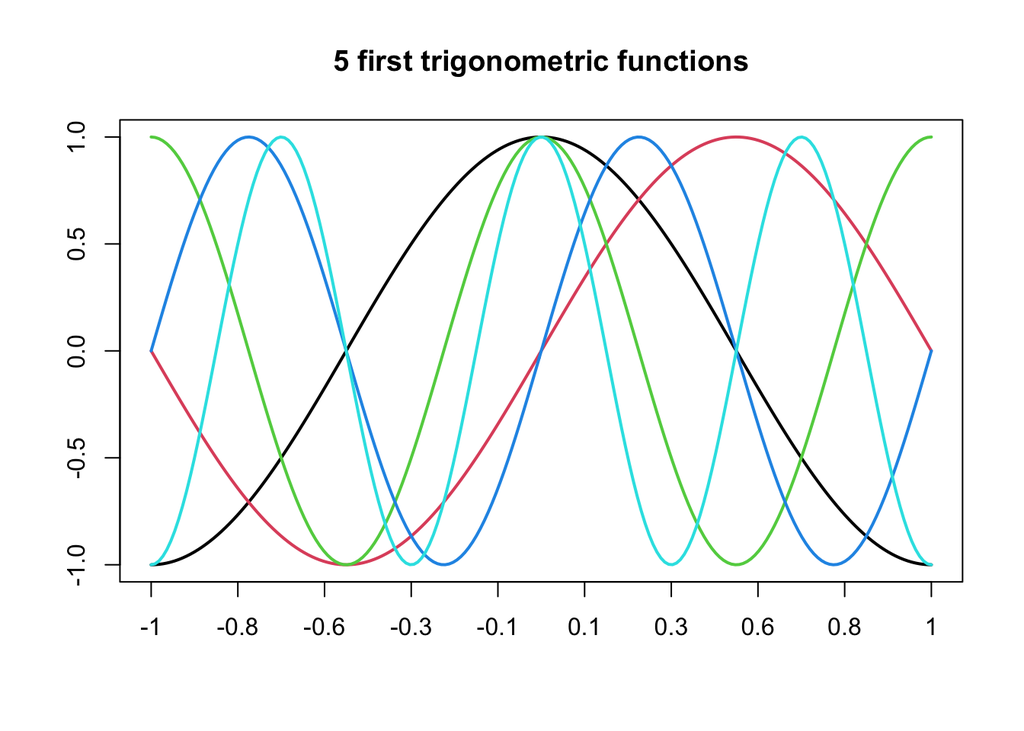

```r
trigof = function(K,gridpoints){
  # K first trigonometric functions
  # output is matrix of dimensions (K*length(gridpoint))
  B = matrix(nrow=K,ncol=length(gridpoints))
  for(kk in 1:K){
    even.true = ((kk %% 2) == 0)
    if(even.true){
      p = kk/2
      B[kk,] = sin(pi*p*gridpoints)
    }else{
      p = (kk+1)/2
      B[kk,] = cos(pi*p*gridpoints)
    }
  }
  return(B)
}
# matrix "TRIGOF" contains trigonometric functions, each of them valued at "Grid" points (row 1 --> trigonometric function 1, row 2 --> trigonometric function 2, ...)
TRIGOF = trigof(nbtrigof, Grid)
# display trigonometric functions
ts.plot(t(TRIGOF), gpars = list(xaxt = "n", xlab = "", col = 1:nrow(TRIGOF), lwd = 2, main = paste0(nbtrigof, " first trigonometric functions")))
values = round(seq(-1, 1, length = 10), digits = 1)
axis(1, at = seq(1, grid.size, length = 10), labels = values)
```

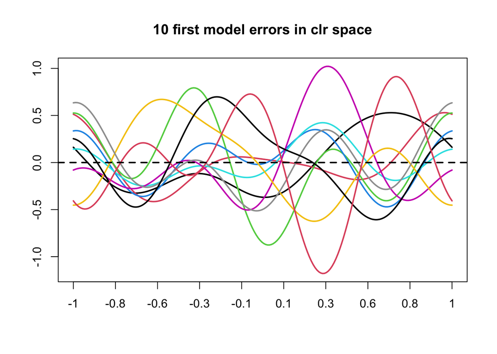

```r
# "At" zero-mean gaussian rrv
At = matrix(rnorm(nbtrigof * N, mean = 0, sd = sigma), nrow = N)
ETA = At %*% TRIGOF
# display m first $\eta_t$'s
m = 10
ts.plot(t(ETA[1:m, ]), gpars = list(xaxt = "n", xlab = "", col = 1:m, lwd = 2, main = paste0(m, " first model errors in clr space")))
values = round(seq(-1, 1, length = 10), digits = 1)
axis(1, at = seq(1, grid.size, length = 10), labels = values)
abline(h = 0, lwd = 2, lty = 2)
```

### Come back to corresponding model errors $\epsilon_1, \, \epsilon_2, \, \ldots$ in the Bayes space

Come back to $\epsilon_t$’s with the inverse of the clr transformation: $\epsilon_t = \mbox{clr}^{-1}(\eta_t)$

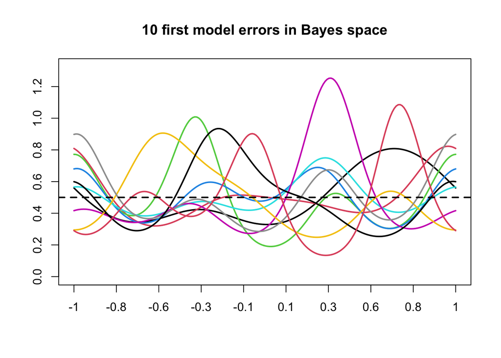

```r
library(pracma) # package containing the "trapz" routine
NUMERATOR = exp(ETA)
Denominator = 0
for(jj in 1:N){
  Denominator[jj] = trapz(Grid, NUMERATOR[jj, ])
}
EPSILON = NUMERATOR / Denominator
# display m first $\epsilon_t$'s
m = 10
ymax = max(EPSILON)
ts.plot(t(EPSILON[1:m, ]), gpars = list(xaxt = "n", xlab = "", col = 1:m, lwd = 2, ylim = c(0, ymax), main = paste0(m, " first model errors in Bayes space")))
values = round(seq(-1, 1, length = 10), digits = 1)
axis(1, at = seq(1, grid.size, length = 10), labels = values)
abline(h = 1/2, lwd = 2, lty = 2)
```

## Generate the regression operator $m(\cdot)$ and time series of PDF’s

1. $m(f_t)$ represents the PDF of $X_{t+1} = \rho X_t + (1-\rho) Y_{t+1}$ when $f_t$ is the PDF of $X_t$,
2. $f_{t+1}$ is the obtained PDF when adding some model error $\epsilon_t$ to $m(f_t)$.

### Distribution of $Y_t$’s

Set $Y_t \, \sim \, g_t = TN(\mu_t, \nu^2)$ where $TN(\mu_t, \nu^2)$ is the truncated normal distribution over $[-1, \, 1]$ derived from the normal distribution $N(\mu_t, \nu^2)$ where, for some constant $T>0$, $\mu_t = \cos(2 \, \pi \, t \, / \, T)$

### Compute $f_1$

Set $f_1 \equiv g_1$ where $g_1 = TN(\mu_1, \nu^2)$ with $\mu_1 = \cos(2 \, \pi \, / \, T)$

```r
library(truncnorm)
f1 = dtruncnorm(Grid, a = lower, b = upper, mean = cos(2 * pi / T), sd = nu)
PDF = matrix(0, N, grid.size)
REG = matrix(0, N, grid.size)
PDF[1, ] = f1
REG[1, ] = f1
```

### Compute $f_2 = m(f_1) \oplus \epsilon_1$

```r
a = Grid + rho - 1
b = Grid - rho + 1
Lb = pmax(-1, a/rho)
Ub = pmin(1, b/rho)
Arg.v = Grid
Range = Ub - Lb
Boolean = (Range > 0)
m.of.f1 = 0
for(ii in 1:grid.size){
  m.of.f1[ii]=0
  if(Boolean[ii]){
    # select grid points (u_i) between Lb[ii] and Ub[ii]
    Arg.x = Grid[(Grid >= Lb[ii]) & (Grid <= Ub[ii])]
    # compute matrix ARG with ARG(k,i) = (v_j - u_i)/(1 - rho)
    ARG = outer(Arg.v, rho * Arg.x, "-")/(1-rho)
    # compute matrix G with G(j,i) = g[(v_j - u_i)/(1 - rho)]
    G = apply(ARG, 2, dtruncnorm, a = lower, b = upper, mean = cos(4*pi/N), sd = nu)
    f1.at.x = dtruncnorm(Arg.x, a = lower, b = upper, mean = cos(2*pi/N), sd = nu)
    Integrand = t(G) * f1.at.x
    m.of.f1[ii] = trapz(Arg.x, Integrand[, ii])/(1 - rho)
  }
}
REG[2, ] = m.of.f1
Numerator = m.of.f1 * EPSILON[1, ]
PDF[2, ] = Numerator / trapz(Grid, Numerator)
```

Remarks:

- REG[2, ] contains $m(f_1)$ valued at grid points (i.e. without model error)
- PDF[2, ] contains $m(f_1) \oplus \epsilon_1$ valued at grid points (i.e. with model error)

### Iterate to build the whole time series of densities $f_1,\, f_2 = m(f_1)\oplus\epsilon_1,\ldots,\, f_N=m(f_{N-1})\oplus\epsilon_{N-1}$

```r
f.new1 = 0
f.new2 = 0
for(tt in 3:N){
  for(ii in 1:grid.size){
    f.new1[ii]=0
    f.new2[ii]=0
    if(Boolean[ii]){
      # select grid points (x_i) between Lb[ii] and Ub[ii]
      Is.in.range = (Grid >= Lb[ii]) & (Grid <= Ub[ii])
      Arg.x = Grid[Is.in.range]
      # compute matrix ARG with ARG(k,i) = (v_k - rho*x_i)/(1 - rho)
      ARG = outer(Arg.v, rho * Arg.x, "-")/(1-rho)
      # compute matrix G with G(j,i) = g[(v_j - rho*x_i)/(1 - rho)]
      G = apply(ARG, 2, dtruncnorm, a = lower, b = upper, mean = cos(2*pi*tt/T), sd = nu)
      Integrand1 = t(G) * REG[tt-1, Is.in.range]
      Integrand2 = t(G) * PDF[tt-1, Is.in.range]
      # compute m(f) at Grid[ii]
      f.new1[ii] = trapz(Arg.x, Integrand1[, ii])/(1 - rho)
      f.new2[ii] = trapz(Arg.x, Integrand2[, ii])/(1 - rho)
    }
  }
  # compute m(f)+error
  REG[tt, ] = f.new1
  Numerator = f.new2 * EPSILON[tt, ]
  PDF[tt, ] = Numerator / trapz(Grid, Numerator)
}
```

Remarks:

- REG[tt, ] contains $m(f_{tt-1})$ valued at grid points (i.e. without model error)
- PDF[tt, ] contains $m(f_{tt-1}) \oplus \epsilon_{tt-1}$ valued at grid points (i.e. with model error)

## About variabilities

### Assessing variability in model errors $\epsilon_1,\ldots,\epsilon_N$

Compute $tr\, \Gamma_{\epsilon,N}$ with $\Gamma_{\epsilon,N} = N^{-1}\sum_t (\epsilon_t - \overline{\epsilon}) (\epsilon_t - \overline{\epsilon})^T$ $\Rightarrow$ $\Gamma_{\epsilon,N} = N^{-1}\sum_t (\epsilon_t - \overline{\epsilon})^T (\epsilon_t - \overline{\epsilon})$

```r
varepsilon = sum(diag(cov(t(EPSILON))))/N
varepsilon
```

```
## [1] 0.02695744
```

#### Assessing variability in $f_1,\ldots,f_N$ with model error (PDFs containing in matrix **PDF**)

Compute $tr\, \Gamma_{f_t,N}$ with $\Gamma_{f_t,N} = N^{-1}\sum_t (f_t - \overline{f}) (f_t - \overline{f})^T$ $\Rightarrow$ $tr\, \Gamma_{f_t,N} = N^{-1}\sum_t (f_t - \overline{f})^T (f_t - \overline{f})$

```r
varf = sum(diag(cov(t(PDF))))/N
varf
```

```
## [1] 1.283937
```

#### Assessing variability in $m(f_1),\ldots,m(f_{N-1})$ without model error (PDFs containing in matrix **REG**)

Compute $tr\, \Gamma_{m(f_t),N}$ with $\Gamma_{m(f_t),N} = N^{-1}\sum_t (m(f_t) - \overline{m(f)}) (m(f_t) - \overline{m(f)})^T$ $\Rightarrow$ $tr\, \Gamma_{m(f_t),N} = N^{-1}\sum_t (m(f_t) - \overline{m(f)})^T (m(f_t) - \overline{m(f)})$

```r
varreg = sum(diag(cov(t(REG))))/N
varreg
```

```
## [1] 0.05340837
```

#### Assessing noise-to-signal ratio

```r
nsr = varepsilon / varreg
nsr
```

```
## [1] 0.5047419
```

### Display simulated time series of PDFs with a 3D plot

```r
library(colorRamps)
### create a N-colorpalette with "colorRampPalette" R function from "cold" to "warm"
colfunc = colorRampPalette(c("orange", "springgreen", "royalblue", "black"))
#plot(rep(1, N), col=(colfunc(100)), pch = 19, cex = 2)
Colors = colfunc(N)
library(rgl)
plot3d(cbind(Grid, rep(1, grid.size), PDF[1, ]), ylim = c(0, N + 1), type = "l", col = Colors[1], lwd = 3)
for(tt in 2:N){
  plot3d(cbind(Grid, rep(tt, grid.size), PDF[tt, ]), add = TRUE, type = "l", col = Colors[tt], lwd = 3)
}
grid3d(c("x", "y+", "z"))
aspect3d(1, 1, 1)
rglwidget()
```

[interactive chart not shown]

Remark: of course, any change on the parameters at the beginning will provide different time series of PDFs.